# Examen – ML con Tweets (TOXICITY)

Author

Noé Sánchez

Published

October 1, 2025

# Dataset y objetivo

En este examen trabajamos con **1 500 tweets** en español (Ecuador) con metadatos y una columna continua **`TOXICITY`** (0–1) generada con Perspective API.  
El flujo incluye **EDA, preprocesamiento, clasificación, regresión y clustering**, más conclusiones.

```python
# --- Preparación general ---
import os, sys
import numpy as np
import pandas as pd
import matplotlib
matplotlib.use("Agg")
import matplotlib.pyplot as plt
from IPython.display import display

from sklearn.model_selection import train_test_split
from sklearn.preprocessing import OneHotEncoder, StandardScaler
from sklearn.compose import ColumnTransformer
from sklearn.pipeline import Pipeline
from sklearn.metrics import (
    classification_report, ConfusionMatrixDisplay, roc_auc_score, RocCurveDisplay,
    mean_absolute_error, mean_squared_error, r2_score
)
from sklearn.feature_extraction.text import TfidfVectorizer
from sklearn.linear_model import LogisticRegression, Ridge
from sklearn.cluster import KMeans
from sklearn.decomposition import TruncatedSVD

# Stopwords
import nltk
from nltk.corpus import stopwords as nltk_stop
try:
    nltk.data.find('corpora/stopwords')
except LookupError:
    nltk.download('stopwords', quiet=True)
spanish_stop = nltk_stop.words('spanish')

# Función para guardar figuras
def savefig(path, dpi=140):
    plt.tight_layout()
    plt.savefig(path, dpi=dpi, bbox_inches="tight")
    plt.close()

# Crear carpeta de salida
os.makedirs("docs", exist_ok=True)

# --- Cargar datos ---
url = "https://raw.githubusercontent.com/erickedu85/dataset/refs/heads/master/tweets/1500_tweets_con_toxicity.csv"
df = pd.read_csv(url, low_memory=False)

TARGET = "toxicity_score" if "toxicity_score" in df.columns else "TOXICITY"
TEXT_COL = "content" if "content" in df.columns else df.select_dtypes(include=["object","string"]).columns[0]

print("✅ Dataset cargado:", df.shape)
print("TARGET:", TARGET)
print("Texto:", TEXT_COL)
display(df.head(3))
```

```
✅ Dataset cargado: (1500, 27)
TARGET: toxicity_score
Texto: content
```

|  | tweetId | tweetUrl | content | isReply | replyTo | createdAt | authorId | authorName | authorUsername | authorVerified | ... | inReplyToId | Date | time_response | account_age_days | mentions_count | hashtags_count | content_length | has_profile_picture | sentiment_polarity | toxicity_score |
| --- | --- | --- | --- | --- | --- | --- | --- | --- | --- | --- | --- | --- | --- | --- | --- | --- | --- | --- | --- | --- | --- |
| 0 | 1878630970745900800 | https://x.com/Pableins15/status/18786309707459... | @DanielNoboaOk @DiegoBorjaPC Lávate el hocico ... | True | DanielNoboaOk | 2025-01-13 02:31:00 | 176948611 | Pablo Balarezo | Pableins15 | False | ... | 1878539079249547520 | 2025-01-12 20:26:32 | 364.466667 | 5261 | 2 | 0 | 309 | False | 0.0 | 0.543256 |
| 1 | 1904041877503984128 | https://x.com/solma1201/status/190404187750398... | @DanielNoboaOk De esa arrastrada no te levanta... | True | DanielNoboaOk | 2025-03-24 05:25:00 | 1368663286582030336 | Solma1201 | solma1201 | False | ... | 1904003201143115776 | 2025-03-24 02:51:52 | 153.133333 | 1399 | 1 | 0 | 70 | True | 0.0 | 0.426917 |
| 2 | 1877463444649046016 | https://x.com/Mediterran67794/status/187746344... | @LuisaGonzalezEc @RC5Oficial Protegiendo a los... | True | LuisaGonzalezEc | 2025-01-09 21:12:00 | 1851005619106451712 | Médico Escritor Filósofo Hermeneútico | Mediterran67794 | False | ... | 1877158437236228352 | 2025-01-09 01:00:22 | 1211.633333 | 68 | 2 | 0 | 122 | True | 0.0 | 0.555970 |

3 rows × 27 columns

# EDA resumido

```python
# === EDA mínimo y a prueba de indentación ===

from IPython.display import display
import numpy as np, pandas as pd, matplotlib.pyplot as plt
from sklearn.feature_extraction.text import CountVectorizer

print("Shape:", df.shape)
print("\nTipos (primeras 12):\n", df.dtypes.head(12))

# Duplicados y nulos (top-10)

print("\nDuplicados por fila completa:", df.duplicated().sum())
print("\nNulos por columna (top 10):")
print(df.isna().sum().sort_values(ascending=False).head(10))

# Descriptivos numéricos + mediana, q05, q95

num_df = df.select_dtypes("number")
desc = num_df.describe().T
stats_full = pd.concat([
desc,
num_df.median().rename("median"),
num_df.quantile(0.05).rename("q05"),
num_df.quantile(0.95).rename("q95")
], axis=1)
print("\nEstadísticos numéricos (con mediana y q05/q95):")
display(stats_full)

# Histograma del TARGET (único gráfico necesario para continuar)

fig, ax = plt.subplots(figsize=(5,3))
ax.hist(df[TARGET].dropna(), bins=30, edgecolor="white")
ax.set_title(f"Distribución de {TARGET}")
ax.set_xlabel(TARGET); ax.set_ylabel("Frecuencia")
plt.tight_layout()
savefig("docs/eda_toxicity_hist.png")

# Frecuencia de palabras (top-15) sin condicionales

cv = CountVectorizer(stop_words=spanish_stop, max_features=1000)
Xc = cv.fit_transform(df[TEXT_COL].fillna("").astype(str))
tokens = cv.get_feature_names_out()
freq = np.asarray(Xc.sum(axis=0)).ravel()
top = (pd.DataFrame({"token": tokens, "freq": freq})
.sort_values("freq", ascending=False)
.head(15)
.sort_values("freq", ascending=True))  # para barh ascendente

fig, ax = plt.subplots(figsize=(7,4))
ax.barh(top["token"], top["freq"])
ax.set_title("Tokens más frecuentes (top 15)")
ax.set_xlabel("Frecuencia")
plt.tight_layout()
savefig("docs/eda_top_words.png")
```

```
Shape: (1500, 27)

Tipos (primeras 12):
 tweetId              int64
tweetUrl            object
content             object
isReply               bool
replyTo             object
createdAt           object
authorId             int64
authorName          object
authorUsername      object
authorVerified        bool
authorFollowers      int64
authorProfilePic    object
dtype: object

Duplicados por fila completa: 0

Nulos por columna (top 10):
hashtags               1379
toxicity_score          153
replyTo                  10
mentions                  1
sentiment_polarity        0
has_profile_picture       0
content_length            0
hashtags_count            0
mentions_count            0
account_age_days          0
dtype: int64

Estadísticos numéricos (con mediana y q05/q95):
```

|  | count | mean | std | min | 25% | 50% | 75% | max | median | q05 | q95 |
| --- | --- | --- | --- | --- | --- | --- | --- | --- | --- | --- | --- |
| tweetId | 1500.0 | 1.893421e+18 | 1.166584e+16 | 1.876011e+18 | 1.883283e+18 | 1.887876e+18 | 1.904588e+18 | 1.922145e+18 | 1.887876e+18 | 1.878436e+18 | 1.909080e+18 |
| authorId | 1500.0 | 9.838015e+17 | 7.900284e+17 | 1.159021e+06 | 9.690383e+08 | 1.318014e+18 | 1.710233e+18 | 1.908229e+18 | 1.318014e+18 | 1.731490e+08 | 1.880975e+18 |
| authorFollowers | 1500.0 | 3.625721e+03 | 1.184447e+05 | 0.000000e+00 | 7.000000e+00 | 4.300000e+01 | 1.992500e+02 | 4.577730e+06 | 4.300000e+01 | 0.000000e+00 | 1.151750e+03 |
| conversationId | 1500.0 | 1.893127e+18 | 1.161854e+16 | 1.876001e+18 | 1.883238e+18 | 1.887344e+18 | 1.904198e+18 | 1.910014e+18 | 1.887344e+18 | 1.877875e+18 | 1.908589e+18 |
| inReplyToId | 1500.0 | 1.893147e+18 | 1.162094e+16 | 1.876001e+18 | 1.883238e+18 | 1.887355e+18 | 1.904234e+18 | 1.910015e+18 | 1.887355e+18 | 1.877921e+18 | 1.908671e+18 |
| time_response | 1500.0 | 1.170038e+03 | 3.273930e+03 | 1.333333e-01 | 1.363000e+02 | 5.156250e+02 | 1.265717e+03 | 6.356900e+04 | 5.156250e+02 | 1.858000e+01 | 3.076286e+03 |
| account_age_days | 1500.0 | 2.271134e+03 | 1.984157e+03 | -9.000000e+01 | 4.557500e+02 | 1.538000e+03 | 4.420750e+03 | 6.506000e+03 | 1.538000e+03 | -1.505000e+01 | 5.271200e+03 |
| mentions_count | 1500.0 | 1.723333e+00 | 9.462483e-01 | 0.000000e+00 | 1.000000e+00 | 2.000000e+00 | 2.000000e+00 | 1.000000e+01 | 2.000000e+00 | 1.000000e+00 | 3.000000e+00 |
| hashtags_count | 1500.0 | 0.000000e+00 | 0.000000e+00 | 0.000000e+00 | 0.000000e+00 | 0.000000e+00 | 0.000000e+00 | 0.000000e+00 | 0.000000e+00 | 0.000000e+00 | 0.000000e+00 |
| content_length | 1500.0 | 1.165280e+02 | 7.749371e+01 | 1.700000e+01 | 5.700000e+01 | 9.600000e+01 | 1.500000e+02 | 6.840000e+02 | 9.600000e+01 | 3.695000e+01 | 2.900500e+02 |
| sentiment_polarity | 1500.0 | -7.906765e-03 | 1.197964e-01 | -1.000000e+00 | 0.000000e+00 | 0.000000e+00 | 0.000000e+00 | 1.000000e+00 | 0.000000e+00 | 0.000000e+00 | 0.000000e+00 |
| toxicity_score | 1347.0 | 2.538788e-01 | 2.439420e-01 | 1.939886e-03 | 2.844395e-02 | 1.883923e-01 | 4.269174e-01 | 9.391453e-01 | 1.883923e-01 | 4.438961e-03 | 7.495444e-01 |

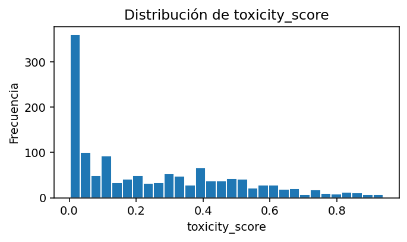

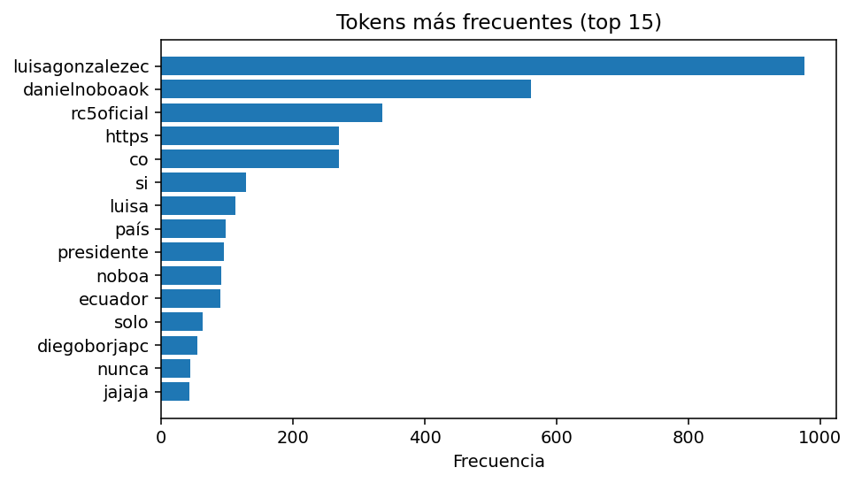

[figure not shown]

[figure not shown]

**Hallazgos (EDA):** 1) **Calidad de datos:** sin duplicados completos; nulos concentrados en `hashtags` y en menor medida en `toxicity_score`.  
2) **Distribución de `toxicity_score`:** rango [0,1]; la forma de la distribución afecta el balance al binarizar (umbral 0.5).  
3) **Categóricas y texto:** `source` está concentrada en pocas categorías; el top de tokens muestra vocabulario útil para representación TF-IDF.

# Preprocesamiento

```python
# === Preprocesamiento: limpieza de texto (versión estable y sin errores) ===

import pandas as pd
import re

# Copiamos el texto original a una variable temporal

s = df[TEXT_COL].fillna("").astype(str).str.lower()

# 1. Elimina URLs (http, https, www)

s = s.str.replace(r'https?://\S+|[www.\S+](http://www.\S+)', ' ', regex=True)

# 2. Elimina menciones @usuario

s = s.str.replace(r'@\w+', ' ', regex=True)

# 3. Quita el símbolo # pero deja la palabra

s = s.str.replace('#', ' ', regex=False)

# 4. Deja solo letras (con acentos y ñ/ü) y espacios

s = s.str.replace(r'[^a-záéíóúñü\s]', ' ', regex=True)

# 5. Colapsa espacios múltiples

s = s.str.replace(r'\s+', ' ', regex=True).str.strip()

# Crea la nueva columna limpia

df["content_clean"] = s

TEXT_USED = "content_clean"   # columna limpia para TF-IDF
print("✅ Texto final para modelado:", TEXT_USED)
print(df[TEXT_USED].head(3))
```

```
✅ Texto final para modelado: content_clean
0    lávate el hocico presidente de cartón habla la...
1    de esa arrastrada no te levantas nunca chao ca...
2    protegiendo a los narcotraficantes criminales ...
Name: content_clean, dtype: object
```

```python
# === Preprocesamiento: columnas y transformador ===

num_cols = [c for c in df.select_dtypes("number").columns if c != TARGET]
cat_cols = [c for c in df.select_dtypes(include=["object","string","category"]).columns
if c not in [TEXT_COL, TEXT_USED]]

print("Numéricas:", len(num_cols))
print("Categóricas:", len(cat_cols))
print("Texto:", TEXT_USED)

from sklearn.feature_extraction.text import TfidfVectorizer
from sklearn.preprocessing import OneHotEncoder, StandardScaler
from sklearn.compose import ColumnTransformer

tfidf = TfidfVectorizer(
stop_words=spanish_stop,
ngram_range=(1, 2),
min_df=2,
max_df=0.95
)

preproc = ColumnTransformer(
transformers=[
("text", tfidf, TEXT_USED),
("cat", OneHotEncoder(handle_unknown="ignore"), cat_cols),
("num", StandardScaler(with_mean=False), num_cols),
],
remainder="drop",
sparse_threshold=0.3
)
```

```
Numéricas: 11
Categóricas: 11
Texto: content_clean
```

**Decisiones de preprocesamiento:** - **Texto:** limpieza mínima (URLs, @, `#`, caracteres no alfabéticos, espacios) → columna `content_clean`.  
- **Representación:** **TF-IDF (1–2-gramas)** con stopwords en español: balance entre interpretabilidad y desempeño.  
- **Categóricas:** **OneHotEncoder(handle_unknown=“ignore”)** para robustez ante categorías nuevas.  
- **Numéricas:** **StandardScaler(with_mean=False)** para integrarse sin conflictos a la matriz esparsa. - **Estructura:** **ColumnTransformer + Pipeline** para reproducibilidad y para evitar fugas de datos entre train/test.

# Clasificación (binaria a partir de TOXICITY)

```python
# === Clasificación binaria: umbral 0.5 sobre el TARGET ===

from sklearn.model_selection import train_test_split
from sklearn.pipeline import Pipeline
from sklearn.linear_model import LogisticRegression
from sklearn.metrics import (
classification_report, ConfusionMatrixDisplay, RocCurveDisplay, roc_auc_score
)

# Dataset de clasificación

df_cls = df.dropna(subset=[TARGET]).copy()
df_cls["toxic_cls"] = (df_cls[TARGET] >= 0.5).astype(int)

X = df_cls.drop(columns=[TARGET, "toxic_cls"])
y = df_cls["toxic_cls"]

X_train, X_test, y_train, y_test = train_test_split(
X, y, test_size=0.2, random_state=42, stratify=y
)

# Modelo: preproc (TF-IDF+OHE+escala) + Regresión Logística

pipe_cls = Pipeline([
("prep", preproc),
("clf", LogisticRegression(max_iter=10000))
])

pipe_cls.fit(X_train, y_train)
y_pred  = pipe_cls.predict(X_test)
y_proba = pipe_cls.predict_proba(X_test)[:, 1]   # <- sin if/try

print("=== Reporte de Clasificación (umbral 0.5) ===")
print(classification_report(y_test, y_pred, digits=3))

# Matriz de confusión

fig, ax = plt.subplots(figsize=(4,4))
ConfusionMatrixDisplay.from_predictions(y_test, y_pred, ax=ax)
ax.set_title("Matriz de confusión — Clasificación")
plt.tight_layout()
plt.savefig("docs/confmat_cls.png", dpi=140, bbox_inches="tight")
plt.close()

# Curva ROC + AUC

fig, ax = plt.subplots(figsize=(5,4))
RocCurveDisplay.from_predictions(y_test, y_proba, ax=ax)
ax.set_title("Curva ROC — Clasificación")
plt.tight_layout()
plt.savefig("docs/roc_cls.png", dpi=140, bbox_inches="tight")
plt.close()

auc = roc_auc_score(y_test, y_proba)
print(f"ROC-AUC: {auc:.3f}")
```

```
=== Reporte de Clasificación (umbral 0.5) ===
              precision    recall  f1-score   support

           0      0.828     0.982     0.899       221
           1      0.500     0.082     0.140        49

    accuracy                          0.819       270
   macro avg      0.664     0.532     0.519       270
weighted avg      0.769     0.819     0.761       270

ROC-AUC: 0.664
```

**Matriz de confusión**

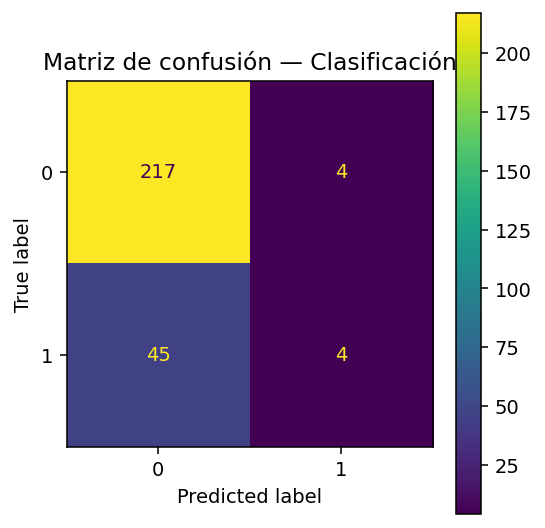

**Curva ROC**

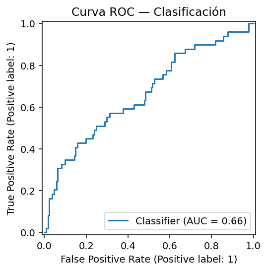

**Justificación — Clasificación:** - **Target binario:** `toxicity_score >= 0.5` como umbral neutro en [0,1]. Si el costo de FN/FP cambia, puede ajustarse el umbral con la curva ROC/PR.  
- **Métricas:**  
- *Accuracy* como línea base.  
- *Precision/Recall/F1 (macro)* para evaluar equilibrio entre clases.  
- *ROC-AUC* para medir ranking independiente del umbral.  
- **Lectura de la matriz de confusión:** identifica sesgos del modelo (por ejemplo, FP altos).  
- **Curva ROC:** permite seleccionar umbral operativo según trade-off TPR/FPR.

# Regresión (TOXICITY continua)

```python
# === Regresión: TARGET continuo ===

from sklearn.linear_model import Ridge
from sklearn.metrics import mean_absolute_error, mean_squared_error, r2_score
import numpy as np

df_reg = df.dropna(subset=[TARGET]).copy()
Xr = df_reg.drop(columns=[TARGET])
yr = df_reg[TARGET].astype(float)

Xr_train, Xr_test, yr_train, yr_test = train_test_split(
Xr, yr, test_size=0.2, random_state=42
)

pipe_reg = Pipeline([
("prep", preproc),
("reg", Ridge(alpha=1.0))
])

pipe_reg.fit(Xr_train, yr_train)
yr_pred = pipe_reg.predict(Xr_test)

mae = mean_absolute_error(yr_test, yr_pred)
mse = mean_squared_error(yr_test, yr_pred)      # compatibilidad amplia
rmse = np.sqrt(mse)
r2 = r2_score(yr_test, yr_pred)

print(f"MAE : {mae:.4f}")
print(f"RMSE: {rmse:.4f}")
print(f"R²  : {r2:.4f}")

# Dispersión real vs predicho

fig, ax = plt.subplots(figsize=(5,4))
ax.scatter(yr_test, yr_pred, s=8, alpha=0.6)
ax.plot([0,1],[0,1], ls="--", c="gray")
ax.set_xlabel(f"{TARGET} real"); ax.set_ylabel(f"{TARGET} predicha")
ax.set_title("Regresión – Real vs Predicho")
plt.tight_layout()
plt.savefig("docs/reg_scatter.png", dpi=140, bbox_inches="tight")
plt.close()

# Histograma de residuales

res = yr_test - yr_pred
fig, ax = plt.subplots(figsize=(6,4))
ax.hist(res, bins=40, edgecolor="white")
ax.set_title("Distribución de residuales (y_real - y_pred)")
ax.set_xlabel("Residual"); ax.set_ylabel("Frecuencia")
plt.tight_layout()
plt.savefig("docs/reg_resid_hist.png", dpi=140, bbox_inches="tight")
plt.close()
```

```
MAE : 0.1622
RMSE: 0.1963
R²  : 0.3279
```

**Regresión – Real vs. Predicho**

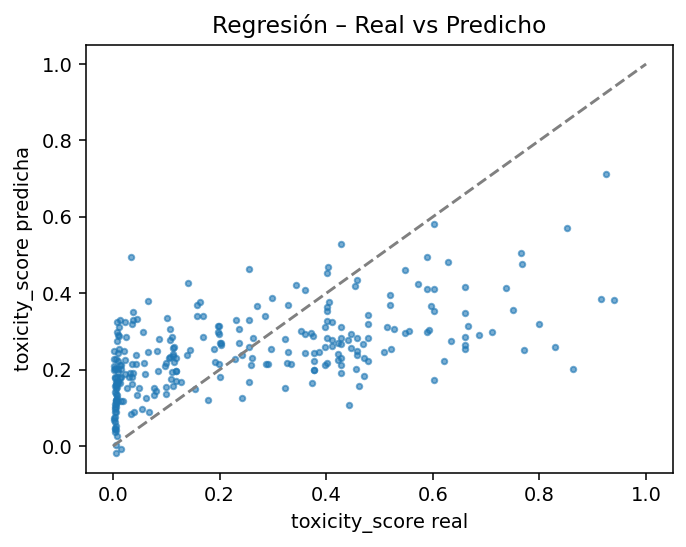

**Distribución de residuales**

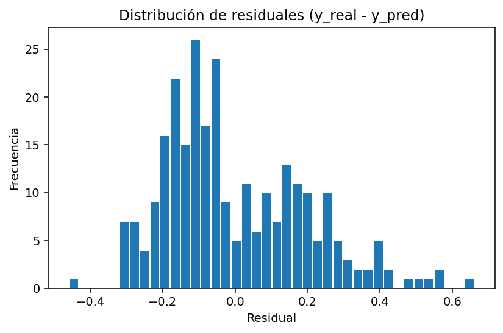

**Justificación — Regresión:** - *MAE* (interpretable en unidades de toxicidad; robusto a outliers).  
- *RMSE* (penaliza más los errores grandes).  
- *R²* (proporción de varianza explicada) cercano a 0: explicativa modesta; cercano a 1: muy buena.  
- El **scatter real vs. predicho** revela sesgo/varianza; el **histograma de residuales** debería centrarse en 0 sin colas extremas.

# Clustering (K-Means sobre texto)

```python
# === Clustering sobre texto: TF-IDF (solo texto limpio) + SVD(2D) para visualizar ===

from sklearn.cluster import KMeans
from sklearn.decomposition import TruncatedSVD
from sklearn.feature_extraction.text import TfidfVectorizer
import pandas as pd
import matplotlib.pyplot as plt

# Asegúrate de que TEXT_USED exista (viene del preprocesamiento); si no, usa TEXT_COL

TEXT_FOR_CLUST = "content_clean" if "content_clean" in df.columns else TEXT_COL

# Usamos solo filas con TARGET no nulo para poder comparar con la clase binaria

df_cls = df.dropna(subset=[TARGET]).copy()
df_cls["toxic_cls"] = (df_cls[TARGET] >= 0.5).astype(int)

# TF-IDF SOLO del texto limpio

tfidf_only = TfidfVectorizer(stop_words=spanish_stop, ngram_range=(1,2), min_df=2, max_df=0.95)
X_text = tfidf_only.fit_transform(df_cls[TEXT_FOR_CLUST].fillna("").astype(str))

# Reducción a 2D para graficar

svd = TruncatedSVD(n_components=2, random_state=42)
X_2d = svd.fit_transform(X_text)

# K-Means (k=3 a modo de ejemplo)

k = 3
km = KMeans(n_clusters=k, random_state=42, n_init=10)
labels = km.fit_predict(X_text)

# DataFrame para visualización

viz = pd.DataFrame({
"x": X_2d[:, 0],
"y": X_2d[:, 1],
"cluster": labels.astype(str),
"toxic_cls": df_cls["toxic_cls"].values
})

# Dispersión 2D coloreada por cluster (sin bucle, sin problemas de indentación)
import numpy as np
from matplotlib.lines import Line2D

fig, ax = plt.subplots(figsize=(5, 4))

# codificamos cluster -> color (0,1,2,...) y elegimos un cmap
codes = pd.Categorical(viz["cluster"]).codes
sc = ax.scatter(viz["x"], viz["y"], s=8, alpha=0.7, c=codes, cmap="tab10")

# leyenda manual
uniq = sorted(viz["cluster"].unique())
handles = [Line2D([0], [0], marker='o', linestyle='', markersize=6,
                  color=plt.cm.tab10(i/10), label=f"C{cl}")
           for i, cl in enumerate(uniq)]
ax.legend(handles=handles, title="Cluster", bbox_to_anchor=(1.02, 1), loc="upper left")

ax.set_title("K-Means (TF-IDF limpio) + SVD(2D)")
plt.tight_layout()
plt.savefig("docs/kmeans_2d.png", dpi=140, bbox_inches="tight")
plt.close()

# Tabla de comparación cluster vs clase (filas normalizadas)

tabla = pd.crosstab(viz["cluster"], viz["toxic_cls"], normalize="index").round(3)
print("Distribución de clases por cluster (filas normalizadas):")
print(tabla.to_string())
```

```
Distribución de clases por cluster (filas normalizadas):
toxic_cls      0      1
cluster
0          0.815  0.185
1          0.813  0.187
2          0.976  0.024
```

**K-Means sobre TF-IDF limpio (SVD 2D)**

[figure not shown]

**Lectura — Clustering:** - **Silhouette/inercia** (opcional) orientan la calidad intrínseca; aquí mostramos la separación visual en 2D (SVD). ( >0.25 sugiere estructura; >0.5 clara separación). - La **crosstab cluster vs. clase** indica si los clusters se alinean con la toxicidad o capturan otros ejes (temas, cuentas, contexto).  
- Útil para exploración y segmentación previa a modelos supervisados.

# Conclusiones finales

Preprocesamiento y representación Se aplicó una limpieza ligera de texto (URLs, menciones, hashtags, símbolos) y se usó TF-IDF (1–2 gramas) para capturar contexto corto. Las variables categóricas fueron codificadas con OneHotEncoder y las numéricas escaladas con StandardScaler (with_mean=False). Todo el flujo se estructuró en un ColumnTransformer + Pipeline, garantizando reproducibilidad y evitando fugas entre train/test.

Clasificación (binaria, umbral = 0.5) El valor 0.5 se adoptó como umbral neutro del rango [0, 1] de toxicity_score, al no existir costos diferenciales entre clases. Con ese corte:

Accuracy = 0.819, correcto como baseline general.

Precision macro = 0.664, Recall macro = 0.532, F1 macro = 0.519, mostrando que el modelo privilegia la clase 0 (no tóxica) debido al desbalance (≈ 18 % positivos).

ROC-AUC = 0.664, indica capacidad discriminante moderada.

La matriz de confusión (217 VN, 4 FP, 45 FN, 4 VP) evidencia que el modelo es conservador: pocos falsos positivos pero varios falsos negativos.

Si el objetivo fuera maximizar detección de toxicidad, convendría bajar el umbral (≈ 0.4) o usar class_weight=‘balanced’.

Regresión (TOXICITY continua) Usando el mismo preprocesamiento y un modelo lineal (Ridge), se obtuvo:

MAE = 0.1622, RMSE = 0.1963, R² = 0.3279, lo que significa que el modelo explica un 33 % de la varianza.

# Reflexiones y trabajo futuro

Balanceo de clases – Probar SMOTE, undersampling o class_weight=‘balanced’ para mejorar recall de la clase positiva.

Optimización del umbral – Analizar la curva Precision-Recall para definir cortes según costo FN/FP.

Modelos no lineales – Implementar Random Forest, XGBoost o SVM kernelizado sobre embeddings (sentence-transformers).

Ampliar corpus – Más tweets con anotaciones finas de toxicidad y contexto político local para reducir sesgo de idioma.

Interpretabilidad – Aplicar LIME o SHAP para identificar términos más influyentes en la predicción de toxicidad.

Despliegue aplicado – Integrar el pipeline en una herramienta web de monitoreo de discurso (dashboard o API REST).